# Report on the Survey of 2018 Nephrology Fellows

#### Exhibit 22: Expected Base Salary by IMG Status and Sex (Mean)

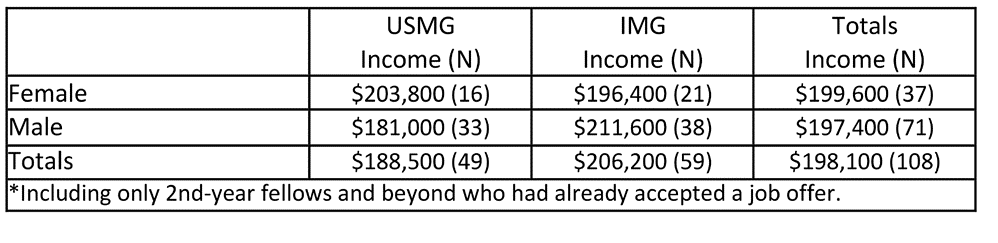

Exhibits 23 and 24 show fellows’ expected base salaries in histogram form. In the histograms IMGs are mostly in higher numbers than USMGs above $160,000 and in lower numbers from $100,000 up to $160,000 with the difference in overall distribution of expected salaries between IMGs and USMGs just reaching statistical significance (p=0.046, Wilcoxon rank-sum test). The difference in the pattern of salaries for male and female fellows was unclear. However, the difference was not statistically significant (p=0.11).

#### Exhibit 23: Distribution of Expected Base Salary for USMGs and IMGs

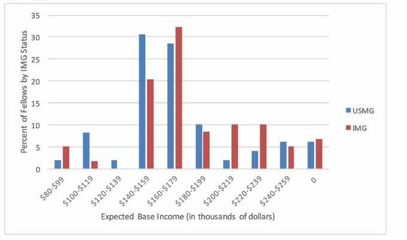

#### Exhibit 24: Distribution of Expected Base Salary by Sex

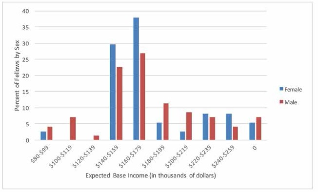

#### Anticipated Additional Incentive Income

Less than half (41.7%) of fellows who had accepted job offers did not anticipate receiving any additional incentive income. Among those expecting to receive incentive income, most reported that they expected to earn less than $15,000, although the range of expected incentives extended beyond $30,000 for 12.5% of fellows and beyond $60,000 for 4.0%.

Exhibits 25 and 26 show fellows’ expected incentive income in histogram form by IMG status and by sex. We found no significant differences in mean expected incentive income between IMGs and USMGs (p=0.12) or male and female fellows (p=0.27).

#### Exhibit 25: Distribution of Incentive Income for USMGs and IMGs

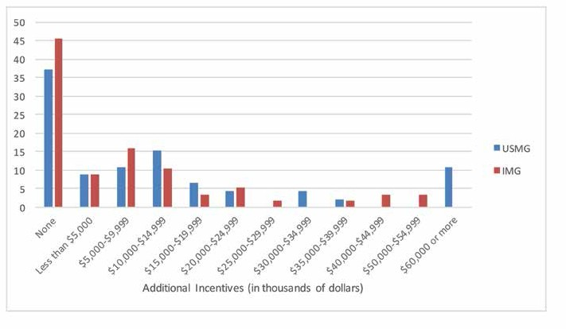

#### Exhibit 26: Distribution of Incentive Income by Sex

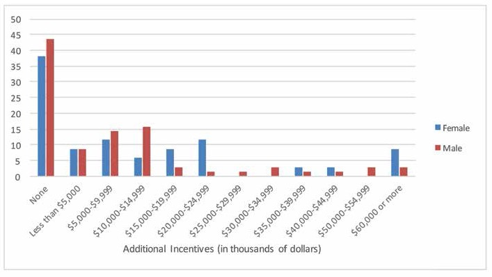

#### Secondary Jobs

Among the respondents who had accepted nephrology jobs, 16 indicated that they planned to take on a second nephrology job in addition to their primary job. The largest response was for hospital care (6 respondents, 37.5%). Other types of secondary jobs included medical directorships with dialysis providers (5 respondents, 31.3%), moonlighting in nephrology inpatient units (4 respondents, 25%), moonlighting in non-nephrology inpatient units (4 respondents, 25%), outpatient nephrology care (1 respondent, 6.3%) and joint ventures with dialysis providers (1 respondent, 6.3%).

Among fellows who reported their expected income from secondary nephrology jobs, three quarters (75%) expected to earn less than $30,000 in their secondary jobs. Only 2 respondents (16.5%) expected to earn more than $50,000 from secondary nephrology jobs.

#### Base Salary Comparisons by Practice Demography and Setting

When we compared base salaries between fellows planning to work in different practice locations (e.g., inner cities, suburban areas) we found the highest average incomes in rural areas ($269,300) and small city ($200,700), with lower incomes in suburban ($188,900), large city areas other than inner city ($196,400), and inner city ($190,300) areas (Exhibit 27). The difference between rural salaries and all others was statistically significant (p<.001). This finding reinforces the 2017 results but stands in contrast to 2016 when the differences were not statistically significant. The only difference between USMGs and IMGs that was statistically significant was for small cities, where IMGs were earning almost $65,000 more than USMGs ($223,900 vs. $159,000, p<.01).

#### Exhibit 27: Distribution of Expected Base Salary by Demography

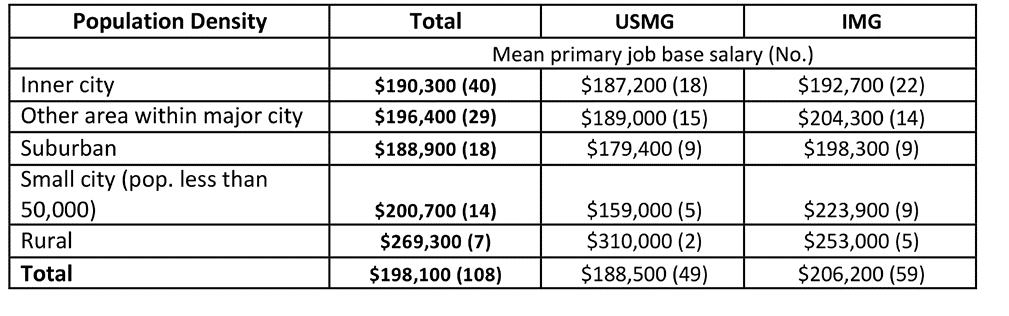

#### Exhibit 28: Distribution of Expected Base Salary by Setting, IMG Status and Gender

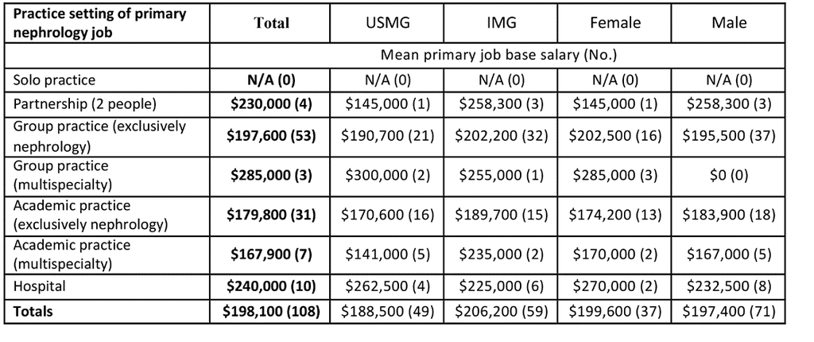

#### Satisfaction with Salary/Compensation

The majority of fellows who had accepted job offers indicated they were satisfied with their salary and compensation. Some 27.3% reported being “very satisfied,” (higher than the correspondent figure of 20.4% in 2017 but lower than the 31.6% in 2016), while 50.9% indicated that they were “somewhat satisfied” with their salary and compensation.

USMGs were more likely to report being “very satisfied” with their salary and compensation (34.7% vs. 21.3%), while IMGs were more likely to report being “somewhat satisfied” (57.4% vs. 42.9%). The differences were not statistically significant (p=.30).

Female fellows were much more likely than males to report being “very satisfied” with their salary and compensation (39.5% vs. 20.8% for males), much higher than the 23.3% in 2017 and approaching the corresponding figure of 48.7% for females in 2016, while male fellows were more likely to report being “somewhat satisfied” (55.6% vs. 42.1%) and “somewhat dissatisfied” (20.8% vs. 13.2%). Again, the differences were not statistically significant (p=0.14).

Those with higher salaries were generally the most satisfied. The difference in mean salary between the ‘very satisfied’ and the ‘somewhat dissatisfied’ groups was around $70,000.

#### Exhibit 29: Distribution of Expected Base Salary by Satisfaction with Salary, IMG Status and Gender

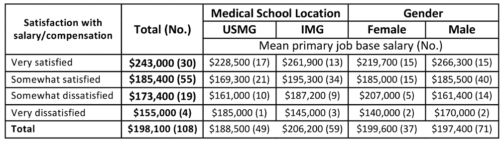

#### Incentives

When asked to identify the incentives they had received for accepting their primary job offers, respondents were most likely to report receiving the following:

- Income guarantees (46.9%)
- Support for MOC and CME (40.7%)
- Career development opportunities (38.1%)
- Relocation allowances (38.1%)
- Sign-on bonus (27.4%)

Educational loan repayment (3.5%) and on-call payments (3.5%) were the least frequently reported incentives. Another 14.2% of respondents who had accepted jobs reported receiving no incentives.

Not surprisingly, we found statistically significant differences between IMG and USMG respondents’ reports of receiving H-1 visa sponsorship (20.3% vs. 2.0%, p<0.05, effect size=0.47) and J-1 visa waivers (17.2% vs. 0%, p=.011, effect size=0.50). A statistically significant difference was also found between IMGs’ and USMGs’ reports of receiving a sign-on bonus (21.9% vs. 34.7%, p<.05. effect size=0.32), support for maintenance of certification and CME (35.9% vs. 46.9%, p<.05, effect size=0.28), and career development opportunities (31.3% vs. 46.9%, p<.05, effect size=0.36). USMGs were more likely than IMGs to report receiving no incentives (20.4% vs. 9.4%, p>.05, effect size=0.33).

We also found large differences between male and female respondents’ reported incentives in regard to income guarantees (males 59.4% vs. females 30.6%), relocation allowances (males 50.0% vs. females 22.4%) and support for maintenance of certification and CME (males 51.6% vs. females 26.5%) but none reached statistical significance (p=.121, .078 and .151 respectively).

Among respondents who reported receiving incentives with their primary job offers, more than two-thirds (69.0%) reported that they were “important” or “very important” in their decision to accept the job. We found a statistically significant difference between IMGs’ and USMGs’ ratings of the importance of the incentives they had received with USMGs more likely than IMGs to rate the incentives they had received as “important” or “very important” (79.3% vs. 53.8%, p<0.01, effect size=0.5).

We found no statistically significant differences between male and female respondents’ ratings of the importance of the incentives they had received (p=0.46).

#### Exhibit 30: Incentives Received

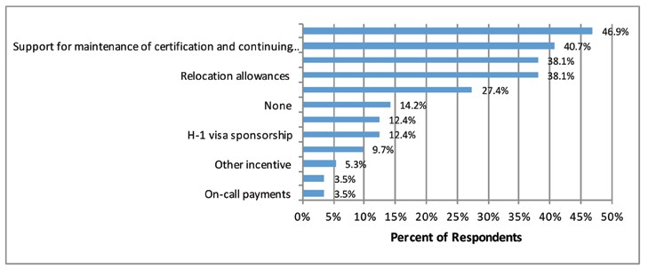

#### Exhibit 31: Primary Job Responsibilities

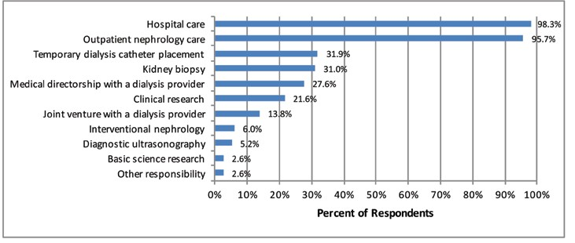

The vast majority of respondents cited hospital care and outpatient nephrology care among their primary job responsibilities (98.3% and 95.7% respectively). Other responsibilities they listed included temporary dialysis catheter placement (31.9%), kidney biopsy (31.0%), medical directorship with a dialysis provider (27.6%) and clinical research (21.6%).

#### Conditions Fellows Expect to Treat

When asked to identify the top 3 conditions they expected to treat in their practice (both primary and secondary jobs), respondents who had accepted job offers most frequently cited ESRD (89.5%), CKD (86.8%), AKI (65.8%), and hypertension (36.0%)—the same conditions as in 2015, 2016 and 2017. The least frequently expected conditions were GN and nephrolithiasis (7.0% each), cystic kidney diseases (3.5%), and kidney cancer (2.6%)— the last two being the same conditions cited in 2016.

#### Exhibit 32: Conditions Fellows Expect to Treat

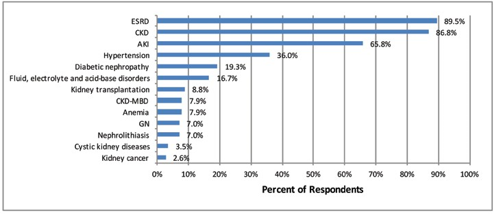

Among dialysis modalities (N=114), respondents who had accepted job offers were most likely to expect to work with in-center hemodialysis (100%), followed by home peritoneal dialysis (71.1%), and home hemodialysis (44.7%). A much smaller group (14.0%) said they anticipated working with nocturnal in-center hemodialysis.

#### Exhibit 33: Consideration Given to a Career Outside Nephrology

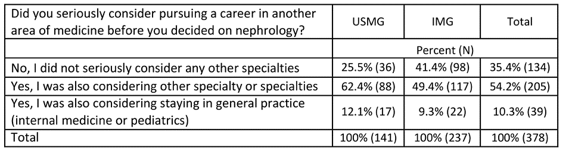

#### Exhibit 34: Level of Preparedness for General Nephrology Practice

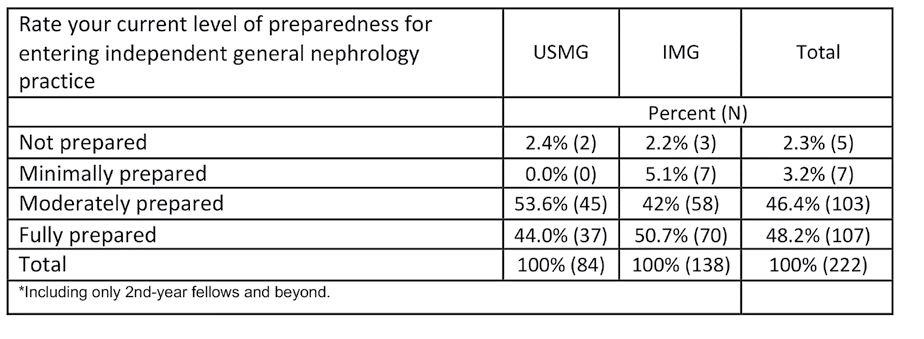

The vast majority of respondents (94.6%) in their second year and beyond rated their level of preparedness for general nephrology practice as “fully prepared” or “moderately prepared”, though less than half felt “fully prepared”. While only 5.3% felt either “minimally prepared” or “not prepared”, this is still of concern. More IMGs than USMGs felt “fully prepared” (50.7% vs. 44.0%) but the difference was not significant.

## Would Fellows Recommend Nephrology?

Despite their mixed assessments of the nephrology job market, a majority (78.8%) of fellows indicated they would recommend nephrology to current medical students and residents, rather higher than the 71.8% in 2016. However, IMGs were less likely than USMGs to report that they would recommend the specialty to others (75.9% vs. 83.7%, respectively, not significant, p=.075). We found no statistically significant difference between male and female fellows’ likelihood of recommending nephrology (p=0.76).

#### Exhibit 35: Would Recommend Nephrology to Medical Students and Residents

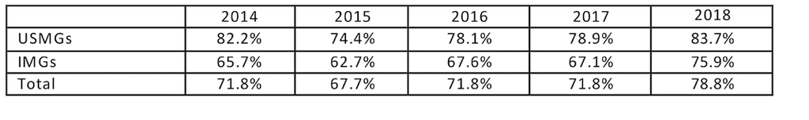

Fellows who said they would recommend nephrology to medical students and residents cited many of the same factors mentioned by previous years’ respondents as reasons for their positive assessments: the intellectual challenge/interest of the field, variety of activities, and long-term patient relationships. Many expressed optimism about an improving job market.

Fellows who said they **would recommend nephrology** to medical students and residents made the following comments to support their assessments:

- A thought-provoking field with lots of unknowns in the field that are currently being investigated with new information and new treatments coming to light
- Because of the diversity of the field and so many different options after completing the basic training such as interventional nephrology, transplant nephrology
- Fascinating pathology, varied job, high patient need. Vulnerable patient population in need of good, humanistic doctors. Huge opportunities for research and academic careers. Ability to sub-sub-specialize
- Great opportunities and clinical need for patient care and research. Practice, though challenging, is enriching
- I love nephrology. The job market is now better. It is an intellectually challenging field and needs a good understanding of basic pathophysiology
- I love what I do. There is always a beauty part behind the problems
- I still love Nephrology, despite what all the naysayers say. I know the economics are changing, and the practice is not what it used to be. Maybe this is my naivete speaking, because I have yet to enter the ‘real world’ of practice. Maybe my opinions will change after a few years. But I see on a daily basis the difference I make in my patient’s lives on both the inpatient and outpatient side of things. I feel that I have a unique understanding of pathophysiology and can contribute meaningfully to the care of those who just need medication adjustments as well as those who need advanced CKD care and renal replacement therapy planning. I think part of my security comes from the fact that in the future, I see many job opportunities available, and I am relatively flexible in terms of geographic location. Others who want to restrict to a certain geographic location may not feel as secure, and may resort to hospitalist work, which is sad because it is a loss to the nephrology workforce. I do see a big future for Nephrology and nephrologists in the era of valuebased healthcare, where preventive approaches can be quantified and followed.
- I think it is a great field and requires a lot of cerebral work. Even though my fellowship is rigorous I enjoy coming to work every day. We need more nephrologist and to inspire more physicians to go into this field.
- I think nephrology is a fascinating field that needs more smart young doctors to join it! Given the downtrend in applicants this is the perfect time to get into the field because more and more jobs will be available.
- I think one has to have an interest in nephrology to go into it. If the med student/resident is suitable I would recommend going into it. Job opportunity-wise, I think the job market is changing. Fewer people entering nephrology and more retiring will create a gap in the job market and raise salaries in the long term. I see some quiet desperation in my local market for nephrologists because so few fellows are coming out of local training programs.
- I think that though it is a subspecialty it is deeply connected to many of the other subspecialties and allows me to practice and exercise knowledge in general internal medicine while also being a consultant. It is also deeply satisfying and also fun to solve electrolyte issues as well as navigate AKI and CKD.
- I was interested in nephrology due to my passion that was obtained through my mentors. I would recommend it for the people who have passion. Salary is only least important for me.
- I would recommend it with the caveat that they should only go into if they really love the subject. If you want a specialty that is 9-5 and makes a lot of money, Nephrology is not it. If you want a specialty with lots of patient education and prolonged continuity of care, this field is perfect.
- Intellectually challenging and stimulating. Very busy work hours during 1st year fellowship and not good lifestyle as a fellow due to high workload. But looking forward to a better quality of life after fellowship as a nephrologist in academic medicine
- Interesting field; can be well compensated in proper setting, good lifestyle, great continuity of care, able to treat the entire patient rather than a single organ system
- It is a beautiful subspecialty where you learn and understand the very complex physiology and mechanisms of the human body. You also become very attached to the patients. The only thing that would make this job perfect is if compensation is related to the number of hours and effort you spend or the patients.
- It is a time-consuming, difficult, but incredibly rewarding field that has numerous opportunities for personal growth, skill development, and leadership.
- It is a very fulfilling discipline in which not only you utilize your brain on a daily basis but also form lifelong relationships with your patients.
- It is a wonderful specialty with wonderful learning opportunities and the ability to establish longitudinal patient relationships.
- It makes you engaged in medicine all the time. Interesting research areas covers wide range of areas. Busy but as long as trying to find balance between life and work, it will be all right
- It’s a nice field if you like physiology, pharmacy and pathology. More importantly it’s a good field for critical thinking and analysis.
- It’s a wonderful field with a lot of intellectual interest. I recognize that job opportunities may be scarce and become scarcer given some of the workforce predictions but I believe that for trainees from wellregarded programs there will continue to be excellent opportunities
- It’s an interesting field that’s really exciting. It’s internal medicine on steroids. Involves the basic sciences and clinical practice
- It’s an interesting specialty deeply rooted in internal medicine and human physiology. Plus, there are no functional symptoms pertaining to Nephrology specifically!
- Most nephrology groups are looking for people and the number of patients will continue to grow. There is variability not found in other subspecialties such as ICU, inpatient floor, dialysis unit, clinic and this helps keep things interesting.
- Most powerful specialty, that keep you up to date in most of Medicine aspects. Also, Nephrology needs smart people that they like to think and like challenging cases.
- Nephrology cannot die. It is a field for never-ending cognitive thirst. There is no other specialty that can widen intellectual horizons as my field. I cannot think of any other field.
- Nephrology is an awesome specialty and you get to see patients with many different pathophysiologies and you develop long-lasting relationships with many of these patients.
- Nephrology is an intellectual specialty with a good amount of general medicine. There is also a good mix of inpatient and outpatient practice.
- Nephrology is the last resorts for all other medical services in helping stabilize the Acid-Base, HTN, electrolytes and volume status of the patient. Nephrology takes care not only of the kidney, but of the whole human organs and systems. I am very glad that I chose this amazing subspecialty.
- Nephrology is very interesting and professionally satisfying subject. For outsiders it may all be about dialysis but the diagnoses can be challenging and fun. Fluid and electrolyte management can get very interesting and satisfying. Nephrology is one of the very few specialties where one will be practicing internal medicine with a touch of salt
- Nephrology is very interesting branch and I love it and it incorporates and touches almost all branch of medicine and keep me updated as an internist!
- Nephrology remains the go-to specialty for medical students who are fascinated by physiology.
- The field will always be attractive to those who enjoy thinking critically about their patients. With the expected physician deficit in the next decade, the low compensation (frequently cited by current medicine residents as the biggest detraction to the subspecialty) will likely increase under regular economic supply/ demand pressures.
- The practice of nephrology is cerebral, not procedural. Nephrology is challenging, but always engaging.
- The practice of nephrology remains one of the most intellectually stimulating fields, and has rewarding interactions with patients, families, and other physicians.
- There is high demand for private practitioners as well as physician-scientists in Nephrology. I would encourage physicians who want to be leaders in their field to pursue Nephrology - there are opportunities open to do so in public policy, research, and clinical practice. Furthermore, Nephrologists have the opportunity to teach their patients and other providers about kidney disease, which is one of the most poorly understood diseases in Medicine.
- They truly need to like nephrology in order to enjoy the training mostly because of the work load and later the compensation. But if someone genuinely likes nephrology I would encourage pursuit if said resident/ student is considering it as a specialty. Better job availability and overall pay here in the southwest is still good, I think.
- Very rewarding field of medicine. You have the opportunity maintain relationships with panel of patients for many years. There are many opportunities for graduating fellows, but you have to choose the opportunity that suits your needs.

Fellows who said they would not recommend nephrology to medical students and residents also cited many of the same factors as previous years: the heavy workload, low compensation, difficult schedule relative to hospital medicine and other specialties, undervaluing of the specialty by other specialties, and lack of opportunities that support visas.

Fellows who said they **would not recommend nephrology** to medical students and residents made the following comments to support their assessments:

- As such Nephrology fellowship is very interesting and wonderful, but life after fellowship is not promising. Lack of job opportunities, long working hours at multiple sites with very poor compensation. Jobs have very bad call schedules (1:2 or 1:3), remote locations and poor quality of life.
- For American graduates with undergraduate and medical school loans it’s hard to recommend a challenging subspecialty where it’s difficult to pay off loans.
- Honestly, lifestyle and reimbursement is very important to me. At the current rate, of the jobs I have seen or Interviewed for, the lifestyle is poor where the work schedule is hectic, unpredictable, involves covering multiple facilities, and there is poor compensation for the amount of work being done. Both hospitalist and primary care have better reimbursements and a better work schedule. I do love Nephrology and May practice some Nephrology in the future, but I doubt I will be solely a nephrologist. I will likely go into primary care or hospitalist as my main focus, and only practice Nephrology on the side. It is very discouraging for someone to put in 2 extra years of training and have a poorer lifestyle and poor reimbursements. Therefore, I would not recommend this field to other students or residents unless this changes. It’s a waste of 2 years is you can’t get a job that is better then being an internist. The whole point of fellowship is to advance your career in a field that you like, and do make a decent living out of doing the subspecialty you chose. I feel the job satisfaction is lacking in Nephrology, more than other subspecialties.
- I love nephrology but the lifestyle is terrible. Long hours, lots of call, small salary, not a lot of jobs, etc.
- I think that the level of mental work, emotional support for dialysis patients, and overall workload in nephrology is not reflected in the average financial compensation for nephrologists. Unless you already like nephrology, e.g. you would be happy practicing nephrology regardless of the paycheck relative to other subspecialties, I do not recommend doing it.
- Lack of good jobs with good work/life balance is not present in nephrology. Getting paid below hospitalist salary on graduation is a depressing factor.
- Lack of respect from other specialties.
- Meager pay for really really hard work. I like nephrology but not worth wasting time for 2 years and then involve in taking care of serious sick patients and paid less.I have to travel approx 1-2 hrs across 2-3 hospitals just to see more patients and earn more but the same as hospitalist who works half days, earns more, and more importantly saves a lot of time. Not worth the time and effort.
- Nephrology fellowship is one of the busiest fellowships with huge patients load, complexity and severity of the cases, despite of that at the end of it there is limited job opportunities and very low payment, compared to doing no fellowship at all, hospitalist job has more flexibility and better compensation
- Nephrology training is very tough and the compensation is not worth your efforts unless you are really interested in Nephrology. Nephrology compensation is a joke, you are compared to Rheumatology and Endocrine, how many of the rheumatologists are taking night and weekend call, for that matter they don’t even come to hospital
- Not enough respect to the amount of work we do, we ought to be treated more appropriately rather than getting the page ‘Come dialyze’
- Not worth the time for the compensation and call/work responsibilities.
- Physicians with long term visa requirement (especially from India, China, …) have 1/4th of jobs compared to other physicians. Most of the jobs in rural areas. Metropolitan jobs don’t pay well. Group practices don’t offer partnership that easy. Considering all of these would highly recommend hospitalist.
- The amount of work nephrologist and the patient population does not correlate with compensation. Most of us graduate with too much student loans and do not see an incentive of making less and getting overworked. Right hospitalist Job is default to all young graduating physician.
- The students and residents should rotate in nephrology consult services and may need to observe some outpatient practices including dialysis units so that it helps them decide their future career.
- Too much work, too little pay, unrealistic expectations, too many fellowship positions for too few jobs.
- Unless he / she really wants to learn and understand renal pathophysiology , there are no lucrative jobs out there. Low salary and high workload
- Very demanding field in terms of knowledge, very few jobs, bad salaries, bad life style, waste of time, as a hospitalist u make almost double and have 2 weeks off a month and u sleep at night
- Quality of life is terrible as a fellow and seems to be poor in practice when compared to other specialties like rheumatology
- Very stressful, fellowship is horribly busy. didn’t sleep good for months. not much money after graduation. hospitalist friends are making double.